# Lab 6 Report

Ollie Murphy

10/13/2021

##### 1. Show the R code you used to define your sse_mean() function

```r
require("palmerpenguins")
rm(list = ls())

sse_mean = function(x)
{
  sd(x, na.rm = TRUE) / sqrt(length(x) - sum(is.na(x)))
}

sse_mean(penguins$body_mass_g)
```

```
## [1] 43.36473
```

```r
sse_mean(mtcars$mpg)
```

```
## [1] 1.065424
```

##### 2. Include the code you used to define your two_group_resample() function into the text input.

```r
set.seed(4587845)
two_group_resample = function(x, n_1, n_2)
{
  mean(
    sample(x, n_1, replace = TRUE), na.rm = TRUE) - mean(
      sample(x, n_2, replace = TRUE), na.rm = TRUE)
}
```

##### 3. Does your function perform Monte Carlo or bootstrap resampling, i.e. does it simulate a null or an alternative hypothesis?

- Monte Carlo/null hypothesis

##### 4. Create histogram of the resampled differences of means.

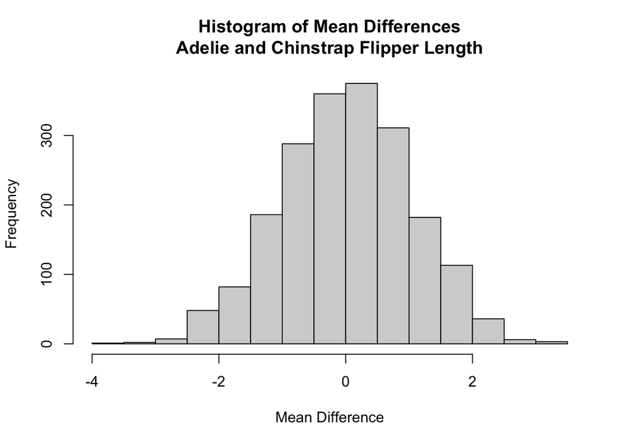

```r
n = 2000
dat_pen = droplevels(subset(penguins, species != "Gentoo"))
mean_differences = c()
for (i in 1:n)
{
  mean_differences = c(
    mean_differences,
    two_group_resample(dat_pen$flipper_length_mm, 68, 152)
  )
}
hist(mean_differences, main = "Histogram of Mean Differences\nAdelie and Chinstrap Flipper Length", xlab = "Mean Difference")
```

##### 5. How many of your resampled differences of means were greater than 5.8?

- There are 0 differences of mean that are greater than 5.8

```r
agg_means = aggregate(
  flipper_length_mm ~ species,
  data = dat_pen,
  FUN = mean,
  na.rm = TRUE)

diff_observed = diff(agg_means[,2])

sum(abs(mean_differences) >= diff_observed)
```

```
## [1] 0
```

##### 6. Given a p value of less than 1 per 10 million, how many simulations do you think you would have to do to see a difference in mean flipper length equal to or greater than 5.8 mm?

- You would likely have to do at least 10 million simulations to see a difference in mean flipper length greater than or equal to 5.8 mm.

### Resampling a Different Variable

##### 7. Include a boxplot of your chosen variable in your report.

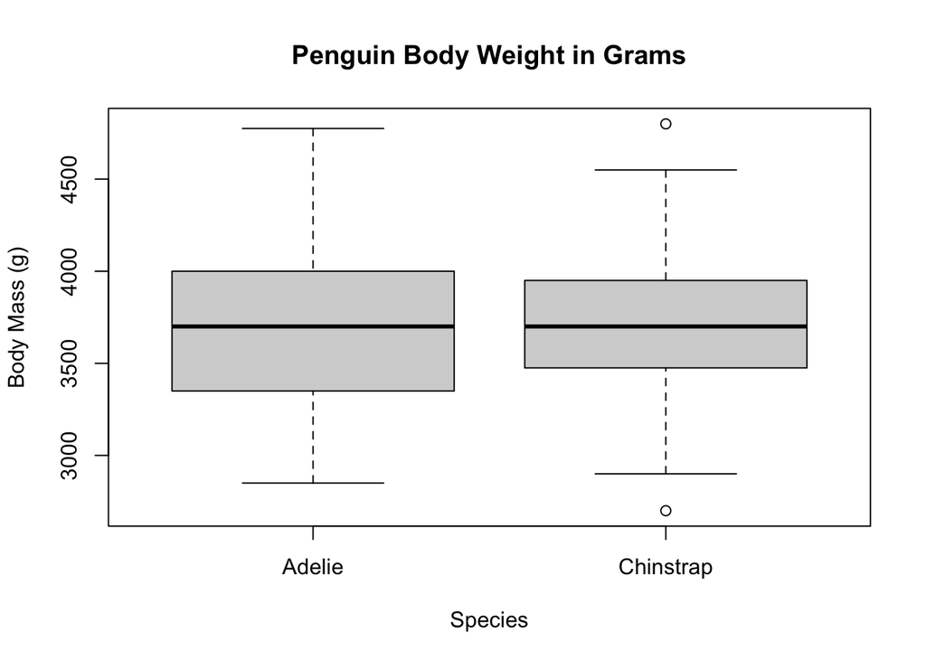

```r
boxplot(dat_pen$body_mass_g ~ dat_pen$species, main = "Penguin Body Weight in Grams", xlab = "Species", ylab = "Body Mass (g)")
```

##### 8. Report the group means and difference between the means.

- Group Means

```r
agg_pen_means = aggregate(
  body_mass_g ~ species,
  data = dat_pen,
  FUN = mean,
  na.rm = TRUE)

agg_pen_means
```

```
##     species body_mass_g
## 1    Adelie    3700.662
## 2 Chinstrap    3733.088
```

- Difference of Means

```r
diff_crit = diff(agg_pen_means[,2])

diff_crit
```

```
## [1] 32.42598
```

##### 9. Interpret the p-value from the t-test output in plain, non-technical English that a non-statistician would understand.

```r
t.test(dat_pen$body_mass_g ~ dat_pen$species)
```

```
##
##  Welch Two Sample t-test
##
## data:  dat_pen$body_mass_g by dat_pen$species
## t = -0.54309, df = 152.45, p-value = 0.5879
## alternative hypothesis: true difference in means between group Adelie and group Chinstrap is not equal to 0
## 95 percent confidence interval:
##  -150.38481   85.53284
## sample estimates:
##    mean in group Adelie mean in group Chinstrap
##                3700.662                3733.088
```

- In this t-test, the p-value of .5879 means that if you repeatedly sampled the Adelie vs. Chinstrap body mass data, roughly 59% of the time the difference of body mass would be greater than or equal to ~32 grams.

### Resampling test with 1000 repetitions

##### 10. How many differences in means were greater than diff_crit?

```r
n = 1000
mean_differences_mass = c()
for (i in 1:n)
{
  mean_differences_mass = c(
    mean_differences_mass,
    two_group_resample(dat_pen$body_mass_g, 68, 152)
  )
}

sum(abs(mean_differences_mass) >= diff_crit)
```

```
## [1] 589
```

##### 11. Include a histogram of your simulation results in your report.

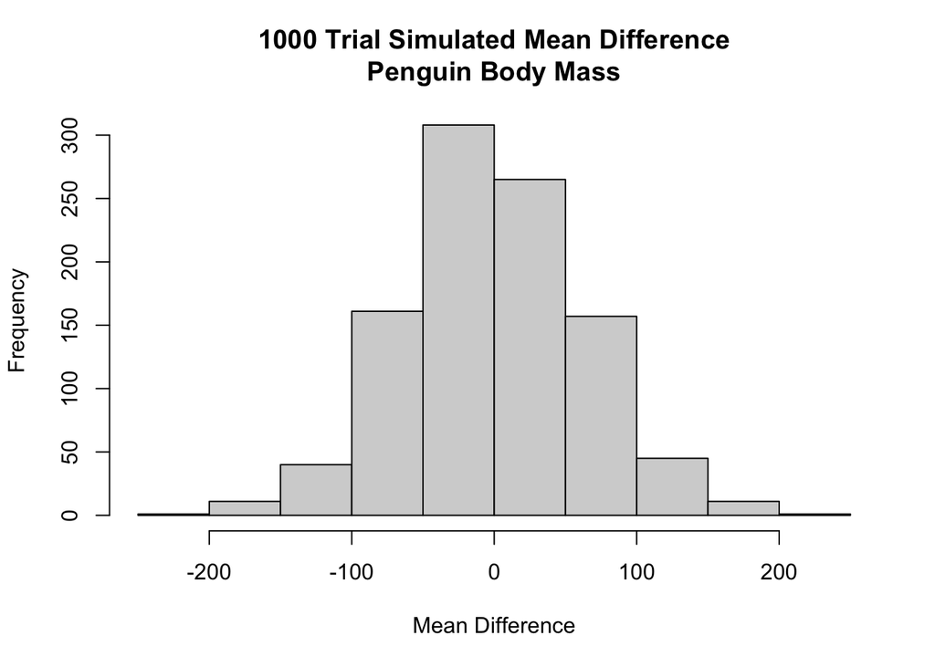

```r
hist(mean_differences_mass, main = "1000 Trial Simulated Mean Difference\nPenguin Body Mass", xlab = "Mean Difference")
```